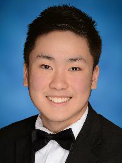

### Andy Wang

AMS & CS @ JHU  
Baltimore, MD  
Email  
[Github](https://github.com/awang124)  
[LinkedIn](https://www.linkedin.com/in/awang124)

# ABOUT

Current third-year B.S. student in the Department of Applied Mathematics & Statistics at Johns Hopkins University, with an additional major in Computer Science. At Hopkins, I work on statistical modeling and computer vision projects, advised by [Dr. Mario Micheli](https://engineering.jhu.edu/faculty/mario-micheli) and [Dr. Anton Dahbura](https://engineering.jhu.edu/faculty/anton-dahbura), centered on Bayesian optical flow estimation using Gaussian process regression, and robust object tracking using deep convolutional neural networks.

# PRIOR EXPERIENCE

Previously, I conducted research with Johns Hopkins Medical Institute’s [Laboratory of Computational Intensive Care Medicine](https://lcicm.jhmi.edu), where I worked on projects relating to unsupervised learning for phenotype discovery in critical care patients. I also worked with [Dr. John Edison](https://engineering.jhu.edu/faculty/john-rajadayakaran-edison) and Johns Hopkins Makerspace to develop wearable position-tracking IoT devices for sports analytics. See the **CV** section for details.

# PROJECTS

The **Projects** section showcases several of my personal machine learning projects, including cardiac arrhythmia detection, stock price forecasting, and spam email detection.

# EDUCATION (COURSEWORK)

Fall 2025: Statistical Learning Theory, Bayesian Statistics, Time Series Analysis, Matrix Analysis  
Spring 2025: Deep Learning, Computer Vision, Mathematical Statistics, Stochastic Processes  
Earlier: Probability, Optimization, Linear Algebra, Data Structures, etc